# Assignment-Resort

Nihal Biswas

2023-05-19

## Importing Data

```r
library(readxl)
setwd("C:\\Users\\Admin\\Downloads")
resort = read_excel("Resort_visit.xls")
head(resort)
```

```
## # A tibble: 6 × 8
##      ID    X1    X2    X3    X4    X5    X6    X7
##   <dbl> <dbl> <dbl> <dbl> <dbl> <dbl> <dbl> <dbl>
## 1     1     1  50.2     5     8     3    43     2
## 2     2     1  70.3     6     7     4    61     3
## 3     3     1  62.9     7     5     6    52     3
## 4     4     1  48.5     7     5     5    36     1
## 5     5     1  52.7     6     6     4    55     3
## 6     6     1  75       8     7     5    68     3
```

- The dataset contains 42 observation and 8 variables.

```r
str(resort)
```

```
## tibble [42 × 8] (S3: tbl_df/tbl/data.frame)
##  $ ID: num [1:42] 1 2 3 4 5 6 7 8 9 10 ...
##  $ X1: num [1:42] 1 1 1 1 1 1 1 1 1 1 ...
##  $ X2: num [1:42] 50.2 70.3 62.9 48.5 52.7 75 46.2 57 64.1 68.1 ...
##  $ X3: num [1:42] 5 6 7 7 6 8 5 2 7 7 ...
##  $ X4: num [1:42] 8 7 5 5 6 7 3 4 5 6 ...
##  $ X5: num [1:42] 3 4 6 5 4 5 3 6 4 5 ...
##  $ X6: num [1:42] 43 61 52 36 55 68 62 51 57 45 ...
##  $ X7: num [1:42] 2 3 3 1 3 3 2 2 3 3 ...
```

- The data is in the correct format.However, the X1 and X7 are labeled.

### Checking for Abnormalities

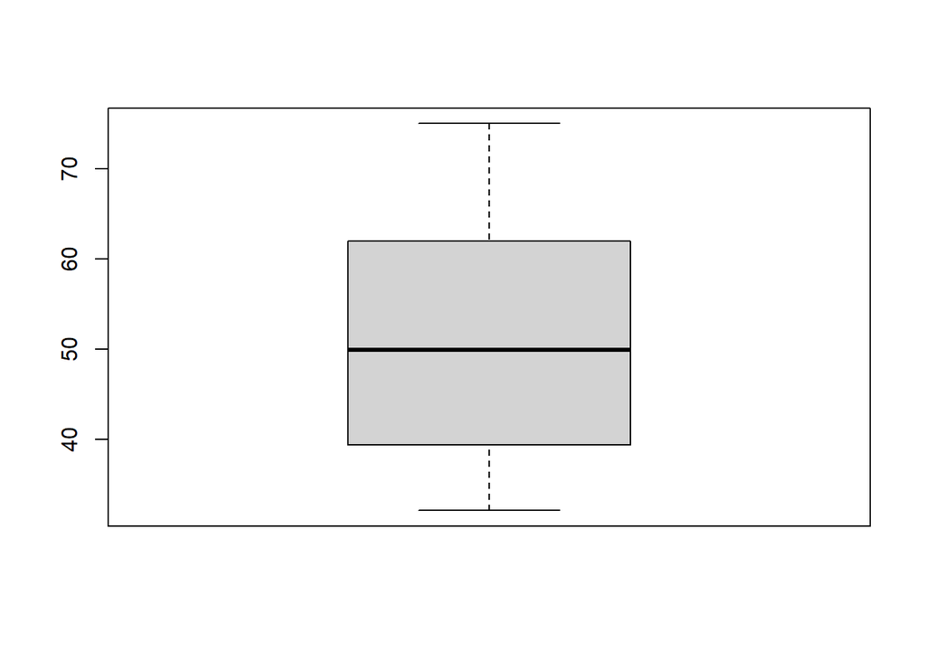

```r
boxplot(resort$X2)
```

- The X2 variable does not have outlaiers.

```r
sum(is.na(resort))
```

```
## [1] 0
```

- The dataset does not contain any missing values.

# Dividing the dataset into testing and training data

```r
set.seed(2)
training_sample=sample(c(TRUE,FALSE),nrow(resort),replace = T,prob = c(0.85,0.15))
training=resort[training_sample,]
testing=resort[!training_sample,]
```

- As we are dividing the data into training and testing dataset it becomes necessary that our main dataset should contain a substantial number of data to perform discriminant analysis.
- Over here the dataset contains 42 number of observations.
- Dividing the dataset into training and testing. Where 85 percent of the observations is taken into the training dataset and rest 15 percent is used for testing.

```r
c("Original_Data"=nrow(resort),"Training_Data"=nrow(training),"Testing_Data"=nrow(testing))
```

```
## Original_Data Training_Data  Testing_Data
##            42            35             7
```

- The training data contains 35 observations and the testing data contains 7 observations.

# Descriptive statistics

```r
aggregate(training,by=list(training$X1),mean)
```

```
##   Group.1       ID X1       X2       X3       X4       X5       X6       X7
## 1       1 15.33333  1 59.92222 5.277778 5.777778 4.388889 52.38889 2.555556
## 2       2 28.17647  2 42.47647 4.235294 4.176471 3.176471 48.70588 1.470588
```

- From the above table we can see that there is a noticeable difference between the annual income is higher for the families who have visited a resort in the last two years than that of the families who have not visited a resort.($ 60,000 compared to $ 42,000).
- We can also see that the families who have visited a resort in the last two months is also spending more on the holiday than the second group.
- The families who have visited the resort in the last two years is having more number of household members than the second group. This can also be a reason for their higher spendings on family holiday.

### Covaraince Variance Martix

```r
library(Hmisc)
rcorr(as.matrix(training[,3:8]),type = "pearson")
```

```
##      X2    X3   X4   X5    X6   X7
## X2 1.00  0.34 0.28 0.39  0.11 0.80
## X3 0.34  1.00 0.11 0.14 -0.22 0.38
## X4 0.28  0.11 1.00 0.13  0.08 0.18
## X5 0.39  0.14 0.13 1.00  0.03 0.21
## X6 0.11 -0.22 0.08 0.03  1.00 0.24
## X7 0.80  0.38 0.18 0.21  0.24 1.00
##
## n= 35
##
##
## P
##    X2     X3     X4     X5     X6     X7
## X2        0.0463 0.1030 0.0197 0.5410 0.0000
## X3 0.0463        0.5122 0.4382 0.1999 0.0249
## X4 0.1030 0.5122        0.4408 0.6507 0.3074
## X5 0.0197 0.4382 0.4408        0.8782 0.2303
## X6 0.5410 0.1999 0.6507 0.8782        0.1707
## X7 0.0000 0.0249 0.3074 0.2303 0.1707
```

# Wilks’ Lambda

```r
library(MASS)
library(klaR)
greedy.wilks(X1~X2+X3+X4+X5+X6+X7,data = training,niveau = 0.9)
```

```
## Formula containing included variables:
##
## X1 ~ X2 + X4 + X5 + X7 + X6 + X3
## <environment: 0x000001dca5fd73d0>
##
##
## Values calculated in each step of the selection procedure:
##
##   vars Wilks.lambda F.statistics.overall p.value.overall F.statistics.diff
## 1   X2    0.4382876            42.293028    2.210253e-07       42.29302836
## 2   X4    0.3978614            24.215011    3.941928e-07        3.25148063
## 3   X5    0.3757645            17.166163    9.429701e-07        1.82296311
## 4   X7    0.3488045            14.002017    1.482051e-06        2.31877568
## 5   X6    0.3366537            11.428388    3.715759e-06        1.04669518
## 6   X3    0.3359443             9.224526    1.319919e-05        0.05912488
##   p.value.diff
## 1 2.210253e-07
## 2 8.049690e-02
## 3 1.864340e-01
## 4 1.379575e-01
## 5 3.144490e-01
## 6 8.095962e-01
```

# Linear Discriminant Model

```r
model1 = lda(X1~X2+X3+X4+X5+X6+X7,data = training)
model1
```

```
## Call:
## lda(X1 ~ X2 + X3 + X4 + X5 + X6 + X7, data = training)
##
## Prior probabilities of groups:
##         1         2
## 0.5142857 0.4857143
##
## Group means:
##         X2       X3       X4       X5       X6       X7
## 1 59.92222 5.277778 5.777778 4.388889 52.38889 2.555556
## 2 42.47647 4.235294 4.176471 3.176471 48.70588 1.470588
##
## Coefficients of linear discriminants:
##            LD1
## X2 -0.07432505
## X3 -0.03362075
## X4 -0.21522833
## X5 -0.28207796
## X6 -0.03301792
## X7 -0.54520706
```

For the above model we are taking a group of 2 types. Hence, we are getting only one LD value.

The model is:

$$\text{}LD1=-0.07432505(X_{2}) -
0.03362075(X_{3}) - 0.21522833(X_{4}) - 0.28207796(X_{5}) - 0.03301792
(X_{6}) - 0.54520706(X_{7})$$

### Data Visualization

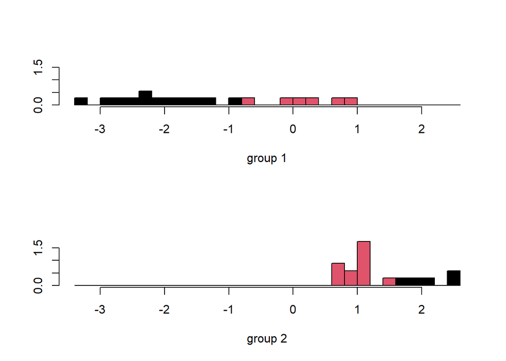

```r
plot(model1, col = as.integer(training$X1))
```

- We can see that for group one and group two only a small portion of the data is overlapping.

## Finding the efficiency of the model using the training data set

```r
lda.train = predict(model1)
training$lda = lda.train$class
table(training$lda,training$X1)
```

```
##
##      1  2
##   1 14  0
##   2  4 17
```

- For the above table we can see that our model is able to correctly predict 14 out of 18 for group 1.
- And for group 2 our model is able to correctly predict 17 out of 17 data.

The efficiency of the model is.

$$Efficiency= (17+14)/35
=>88.57\text{%}$$

## Finding the efficiency of the model using the testing data set

```r
lda.test = predict(model1,testing)
testing$lda = lda.test$class
table(testing$lda,testing$X1)
```

```
##
##     1 2
##   1 2 0
##   2 1 4
```

- For the above table we can see that our model is able to correctly predict 2 out of 3 for group 1.
- And for group 2 our model is able to correctly predict 4 out of 4 data.

The efficiency of the model is.

$$Efficiency= (2+4)/7
=>85.71\text{%}$$

The efficiency is slightly lower that the training prediction.

# Linear Discriminant Analysis for Three Groups

```r
set.seed(2)
training_sample2=sample(c(TRUE,FALSE),nrow(resort),replace = T,prob = c(0.85,0.15))
training2=resort[training_sample2,]
testing2=resort[!training_sample2,]
c("Original_Data"=nrow(resort),"Training_Data"=nrow(training2),"Testing_Data"=nrow(testing2))
```

```
## Original_Data Training_Data  Testing_Data
##            42            35             7
```

- From the above table we can see that the training data contains 35 observations and the testing data contains 7.

# Descriptive statistics

```r
aggregate(training2,by=list(training2$X7),mean)
```

```
##   Group.1       ID       X1       X2       X3       X4       X5       X6 X7
## 1       1 28.36364 1.909091 39.97273 4.181818 4.727273 3.636364 48.63636  1
## 2       2 18.75000 1.500000 50.49167 4.166667 4.666667 3.416667 49.83333  2
## 3       3 18.16667 1.083333 62.92500 5.916667 5.583333 4.333333 53.16667  3
```

- Just like what we have seen from the two variable model, we can see that there is a relation between the annual income earned by families and their spending pattern.As the average family income increases their spending amount in holidays also increases.
- On the other hand we see that families that spend low money on vacation have a greater assimilation towards travel that the families who spend medium amount.
- The same is the situation with X4. We see that the family who spends medium amount has a lower importance attachment towards family holiday than that of the families that are spending less.

## Evaluating the Variance-Covariance matrix

```r
rcorr(as.matrix(training2[,2:7]),type = "pearson")
```

```
##       X1    X2    X3    X4    X5    X6
## X1  1.00 -0.75 -0.28 -0.40 -0.44 -0.24
## X2 -0.75  1.00  0.34  0.28  0.39  0.11
## X3 -0.28  0.34  1.00  0.11  0.14 -0.22
## X4 -0.40  0.28  0.11  1.00  0.13  0.08
## X5 -0.44  0.39  0.14  0.13  1.00  0.03
## X6 -0.24  0.11 -0.22  0.08  0.03  1.00
##
## n= 35
##
##
## P
##    X1     X2     X3     X4     X5     X6
## X1        0.0000 0.1077 0.0164 0.0088 0.1724
## X2 0.0000        0.0463 0.1030 0.0197 0.5410
## X3 0.1077 0.0463        0.5122 0.4382 0.1999
## X4 0.0164 0.1030 0.5122        0.4408 0.6507
## X5 0.0088 0.0197 0.4382 0.4408        0.8782
## X6 0.1724 0.5410 0.1999 0.6507 0.8782
```

# Wilks’ Lambda

```r
greedy.wilks(X7~X1+X2+X3+X4+X5+X6,data=training2, niveau=0.9)
```

```
## Formula containing included variables:
##
## X7 ~ X2 + X3 + X6 + X5 + X1 + X4
## <environment: 0x000001dcac739430>
##
##
## Values calculated in each step of the selection procedure:
##
##   vars Wilks.lambda F.statistics.overall p.value.overall F.statistics.diff
## 1   X2    0.3582380            28.663043    7.357781e-08        28.6630426
## 2   X3    0.3258616            11.652830    4.050124e-07         1.5400226
## 3   X6    0.2827910             8.804734    6.920310e-07         2.2845817
## 4   X5    0.2626720             6.895918    2.438731e-06         1.1106094
## 5   X1    0.2523052             5.548718    1.078793e-05         0.5752349
## 6   X4    0.2409415             4.667622    3.734646e-05         0.6367090
##   p.value.diff
## 1 7.357781e-08
## 2 2.298462e-01
## 3 1.187038e-01
## 4 3.425227e-01
## 5 5.688618e-01
## 6 5.365181e-01
```

# Linear Discriminant Model

```r
model2 = lda(X7~X1+X2+X3+X4+X5+X6,data = training2)
model2
```

```
## Call:
## lda(X7 ~ X1 + X2 + X3 + X4 + X5 + X6, data = training2)
##
## Prior probabilities of groups:
##         1         2         3
## 0.3142857 0.3428571 0.3428571
##
## Group means:
##         X1       X2       X3       X4       X5       X6
## 1 1.909091 39.97273 4.181818 4.727273 3.636364 48.63636
## 2 1.500000 50.49167 4.166667 4.666667 3.416667 49.83333
## 3 1.083333 62.92500 5.916667 5.583333 4.333333 53.16667
##
## Coefficients of linear discriminants:
##            LD1         LD2
## X1 -0.69338845  1.64034474
## X2  0.12321556 -0.01146683
## X3  0.21115872  0.41014905
## X4 -0.09404942  0.21887171
## X5 -0.20549149  0.52644258
## X6  0.04966229  0.05941597
##
## Proportion of trace:
##  LD1  LD2
## 0.94 0.06
```

For the above model we are taking a group of 3 types. Hence, we are getting two LD value.

The LD1 for this model is:

$$\text{}LD1=-0.69338845(X_{1})+0.12321556
(X_{2}) + 0.21115872(X_{3}) - 0.09404942(X_{4}) -0.20549149(X_{5}) +
0.04966229 (X_{6})$$
The LD2 for this model is:

$$\text{}LD1=1.64034474(X_{1})-0.01146683
(X_{2}) + 0.41014905(X_{3}) + 0.21887171(X_{4}) +0.52644258(X_{5}) +
0.05941597 (X_{6})$$

## Visualization

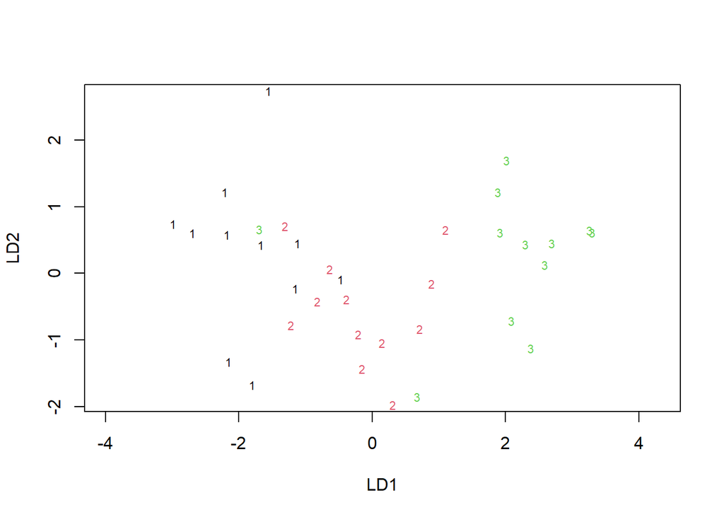

```r
plot(model2,col = as.integer(training2$X7))
```

- We can see from the graph that segregation has not been done as efficiently since there is a overlap between the group 1 and 2. This can also be seen in the descriptive statistics from the earlier table as most of the mean values of certain variables for group 1 and 2 were almost equal.

## Finding the efficiency of the model using the training data set

```r
lda.train2 = predict(model2,training2)
training2$lda = lda.train2$class
table(training2$lda,training2$X7)
```

```
##
##      1  2  3
##   1  9  1  1
##   2  2 10  1
##   3  0  1 10
```

We can see that, in the training data set, the model was able to correctly predict 9 out of 11 correspondents who were spending low on vacation. - Out of Out of 12 correspondents who spent medium amount of money, the model has been able to predict 10 of them correctly. - And, out of 12 correspondents who spent the most amount of money, the model has been able to predict 10 of them correctly. - Thus, the efficiency of the model while using the training data set is =
$$Efficiency= (9+10+10)/35 = 0.8285\text{(~83%)}$$

## Finding the efficiency of the model using the testing data set

```r
lda.test2 = predict(model2,testing2)
testing2$lda = lda.test2$class
table(testing2$lda,testing2$X7)
```

```
##
##     1 2 3
##   1 3 0 0
##   2 0 2 0
##   3 0 0 2
```

- From the above table we can see that surprisingly our model were able to predict all the correspondents to their correct group.
- Thus, the efficiency of the model while using the testing data set is:
  $$Efficiency=100\text{%}$$